# Reproducible Research: Peer Assessment 1

Kami Koleva

18 January 2015

#### Introduction

Data from a personal activity monitoring device was colected by anonymous individual for a period of two months. The data consists of observations of the number of steps that the indivisual did at 5 minute intervals through out the day.

The variables included are:

**steps:** Number of steps taking in a 5-minute interval (missing values are coded as NA)

**date:** The date on which the measurement was taken in YYYY-MM-DD format

**interval:** Identifier for the 5-minute interval in which measurement was taken

##### Basic settings of report

```r
echo = TRUE
options(scipen = 1)
```

#### Loading and preprocessing the data

Download the data file, if the file is not present in the current folder.

```r
if(!file.exists("activity.csv")) {

        print("Downloading DataRow")
        SourceURL <- "https://d396qusza40orc.cloudfront.net/repDataRow%2FDataRow%2Factivity.zip"
        download.file(SourceURL, destfile = "DataRowset.zip", mode = "wb")

        print("Unzipping DataRow!")
        unzip("DataRowset.zip")
        print("Unzipping DataRow Done!")
}
```

Load the data and remove missing records.

```r
Data <- read.csv("activity.csv", colClasses = c("integer", "Date", "factor"))

Data$month <- as.numeric(format(Data$date, "%m"))
summary(Data)
```

```
##      steps             date               interval         month
##  Min.   :  0.00   Min.   :2012-10-01   0      :   61   Min.   :10.00
##  1st Qu.:  0.00   1st Qu.:2012-10-16   10     :   61   1st Qu.:10.00
##  Median :  0.00   Median :2012-10-31   100    :   61   Median :10.00
##  Mean   : 37.38   Mean   :2012-10-31   1000   :   61   Mean   :10.49
##  3rd Qu.: 12.00   3rd Qu.:2012-11-15   1005   :   61   3rd Qu.:11.00
##  Max.   :806.00   Max.   :2012-11-30   1010   :   61   Max.   :11.00
##  NA's   :2304                          (Other):17202
```

```r
DataNA_Removed <- na.omit(Data)
rownames(DataNA_Removed) <- 1:nrow(DataNA_Removed)

head(DataNA_Removed)
```

```
##   steps       date interval month
## 1     0 2012-10-02        0    10
## 2     0 2012-10-02        5    10
## 3     0 2012-10-02       10    10
## 4     0 2012-10-02       15    10
## 5     0 2012-10-02       20    10
## 6     0 2012-10-02       25    10
```

The dat set has the folowing dimnetions:

```r
dim(DataNA_Removed)
```

```
## [1] 15264     4
```

The number of the missing and complete records is:

```r
NumOfMissingRecords  <- sum(is.na(Data))
NumOfCompleteRecords <- sum(complete.cases(Data))
```

The graph bellow will ilustrate better the numbers:

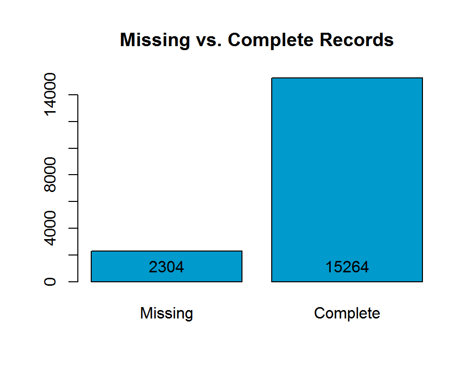

```r
barplot(table(complete.cases(Data)),
        main = "Missing vs. Complete Records",
        xaxt = 'n', col = "deepskyblue3")

axis(side = 1, at = c(.7,1.9),labels = c("Missing","Complete"),tick = FALSE)


text(0.7,0, labels = NumOfMissingRecords,  pos = 3)
text(1.9,0, labels = NumOfCompleteRecords, pos = 3)
```

#### What is mean total number of steps taken per day?

The graph bellow will show the total number of steps for each day of the observed two months period.

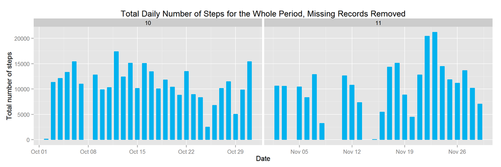

```r
library(ggplot2)

ggplot(DataNA_Removed, aes(date, steps)) +

        geom_bar(stat = "identity",
                 colour = "deepskyblue2",
                 fill = "deepskyblue2",
                 width = 0.6) +

        facet_grid(. ~ month, scales = "free") +

        labs(title = "Total Daily Number of Steps for the Whole Period, Missing Records Removed",
             x = "Date",
             y = "Total number of steps",
             size = rel(0.7))
```

To compute the mean and median of the total daily number of steps, the dat will be Split by day (date):

```r
TotalDailySteps <- aggregate(steps ~ date, Data, na.rm = TRUE, sum)
```

Now the Mean Total Daily Steps can be computed:

```r
MeanOfTotalDailySteps <- mean(TotalDailySteps$steps)
sprintf("MeannOfTotalDailySteps = %.2f", MeanOfTotalDailySteps)
```

```
## [1] "MeannOfTotalDailySteps = 10766.19"
```

Here is the computation needed for the Median of the Total Daily Steps:

```r
MedianOfTotalDailySteps <- median(TotalDailySteps$steps)
sprintf("MedianOfTotalDailySteps = %.2f", MedianOfTotalDailySteps)
```

```
## [1] "MedianOfTotalDailySteps = 10765.00"
```

The code beloow will create a histogram of the total daily steps number:

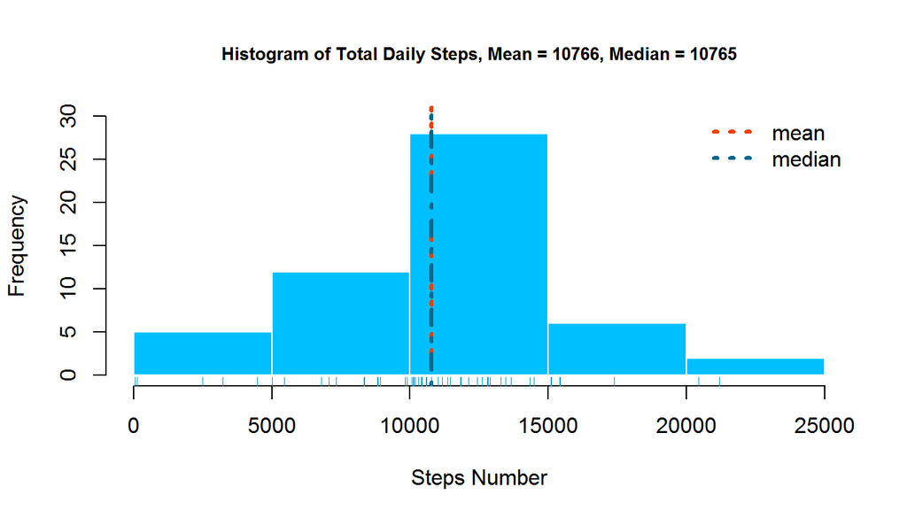

```r
TitleHistogram = paste("Histogram of Total Daily Steps",
                       sprintf("Mean = %d", round(MeanOfTotalDailySteps)),
                       sprintf("Median = %d", round(MedianOfTotalDailySteps)),
                       sep = ", ")
hist(TotalDailySteps$steps,
     col = "deepskyblue1",
     border="white",
     breaks = 5,
     main = TitleHistogram,
     cex.main = 0.8,
     xlab = "Steps Number",
     ylim = c(0, 30),
     xlim = c(0, 25000),
     cex = 0.5)

abline(v = MeanOfTotalDailySteps,   col = "orangered2",  lty = 3, lwd = 3)
abline(v = MedianOfTotalDailySteps, col = "deepskyblue4", lty = 4, lwd = 3)

legend(x = "topright",
       legend = c("mean","median"),
       col = c("orangered2","deepskyblue4"),
       bty ="n", lwd = 3, lty = 3)

rug(TotalDailySteps$steps, col = "deepskyblue3")
```

#### What is the average daily activity pattern?

The code bellow will first preproces the data by aggregating the data by interval and averaging acros all days.

```r
AverageSteps <- aggregate(DataNA_Removed$steps,
                list(interval = as.numeric(as.character(DataNA_Removed$interval))),
                FUN = "mean")
names(AverageSteps)[2] <- "AverageSteps"
```

See below the time series plot of the 5-minute interval and the average number of steps taken, averaged across all days.

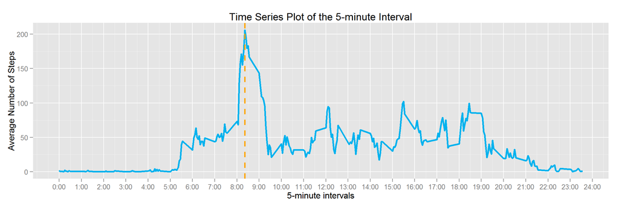

```r
ggplot(AverageSteps, aes(interval, AverageSteps)) +

        geom_line(color = "deepskyblue2", size = 1.2) +

        labs(title = "Time Series Plot of the 5-minute Interval",
             x = "5-minute intervals",
             y = "Average Number of Steps") +

        geom_vline(xintercept = IntervalWithMaxAverageStepsNumber,
                   color ="orange", linetype = "dashed", size = 0.9) +

        scale_x_continuous(breaks = seq(0, 2400, by = 100), labels = paste(0:24,":00", sep=""))
```

Interval containing the maximum number of steps:

```r
AverageSteps[AverageSteps$AverageSteps == max(AverageSteps$AverageSteps), ]
```

```
##     interval AverageSteps
## 104      835     206.1698
```

```r
MaxIntervalAverageStepsNumber = AverageSteps[AverageSteps$AverageSteps == max(AverageSteps$AverageSteps), 2]
MaxIntervalAverageStepsNumber
```

```
## [1] 206.1698
```

```r
IntervalWithMaxAverageStepsNumber = AverageSteps[AverageSteps$AverageSteps == max(AverageSteps$AverageSteps), 1]
IntervalWithMaxAverageStepsNumber
```

```
## [1] 835
```

#### Imputing missing values

To impute the missing values, the mean across all days for the 5-min interval which it occurs willbe used. New data set will be created where all missing values will be subsituted with the estimates, as described above.

```r
DataNA_Imputed <- Data
for (i in 1:nrow(DataNA_Imputed)) {
        if (is.na(DataNA_Imputed$steps[i])) {
                DataNA_Imputed$steps[i] <- AverageSteps[which(DataNA_Imputed$interval[i] == AverageSteps$interval), ]$AverageSteps
        }
}

head(DataNA_Imputed)
```

```
##       steps       date interval month
## 1 1.7169811 2012-10-01        0    10
## 2 0.3396226 2012-10-01        5    10
## 3 0.1320755 2012-10-01       10    10
## 4 0.1509434 2012-10-01       15    10
## 5 0.0754717 2012-10-01       20    10
## 6 2.0943396 2012-10-01       25    10
```

```r
sum(is.na(DataNA_Imputed))
```

```
## [1] 0
```

Barplot Daily total steps for the whole period

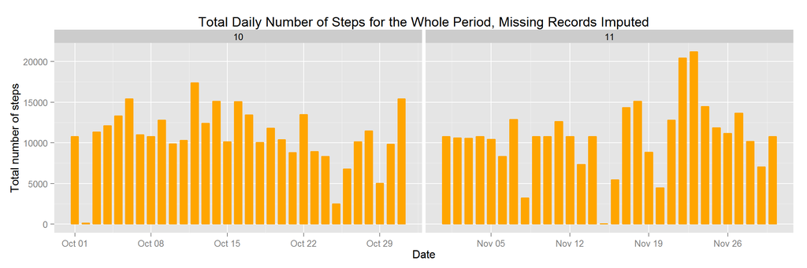

```r
ggplot(DataNA_Imputed, aes(date, steps)) +

        geom_bar(stat = "identity",
                 colour = "orange",
                 fill = "orange",
                 width = 0.7) +

        facet_grid(. ~ month, scales = "free") +

        labs(title = "Total Daily Number of Steps for the Whole Period, Missing Records Imputed",
             x = "Date",
             y = "Total number of steps")
```

Split data by day (date) and calculate total steps dayly

```r
TotalDailyStepsNA_Imputed <- aggregate(steps ~ date, DataNA_Imputed, na.rm = TRUE, sum)
```

Mean Total Daily Steps

```r
MeanOfTotalDailyStepsNA_Imputed <- mean(TotalDailyStepsNA_Imputed$steps)
sprintf("MeannOfTotalDailyStepsNA_Imputed = %.2f", MeanOfTotalDailyStepsNA_Imputed)
```

```
## [1] "MeannOfTotalDailyStepsNA_Imputed = 10766.19"
```

Median Total Daily Steps

```r
MedianOfTotalDailyStepsNA_Imputed <- median(TotalDailyStepsNA_Imputed$steps)
sprintf("MedianOfTotalDailyStepsNA_Imputed = %.2f", MedianOfTotalDailyStepsNA_Imputed)
```

```
## [1] "MedianOfTotalDailyStepsNA_Imputed = 10766.19"
```

```r
summary(TotalDailyStepsNA_Imputed)
```

```
##       date                steps
##  Min.   :2012-10-01   Min.   :   41
##  1st Qu.:2012-10-16   1st Qu.: 9819
##  Median :2012-10-31   Median :10766
##  Mean   :2012-10-31   Mean   :10766
##  3rd Qu.:2012-11-15   3rd Qu.:12811
##  Max.   :2012-11-30   Max.   :21194
```

Histogram Total Steps per day

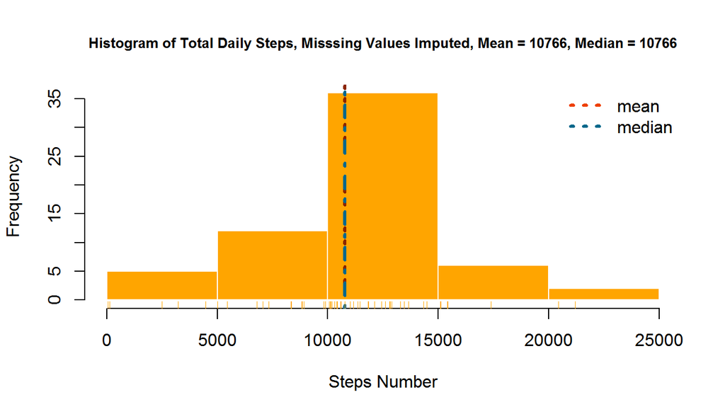

```r
TitleHistogram = paste("Histogram of Total Daily Steps, Misssing Values Imputed",
                       sprintf("Mean = %d", round(MeanOfTotalDailyStepsNA_Imputed)),
                       sprintf("Median = %d", round(MedianOfTotalDailyStepsNA_Imputed)),
                       sep = ", ")
hist(TotalDailyStepsNA_Imputed$steps,
     col = "orange",
     border="white",
     breaks = 5,
     main = TitleHistogram,
     cex.main = 0.8,
     xlab = "Steps Number",
     xlim = c(0, 25000),
     cex = 0.6)

abline(v = MeanOfTotalDailyStepsNA_Imputed,   col = "orangered4",  lty = 3, lwd = 3)
abline(v = MedianOfTotalDailyStepsNA_Imputed, col = "deepskyblue4", lty = 4, lwd = 3)

legend(x = "topright",
       legend = c("mean","median"),
       col = c("orangered2","deepskyblue4"),
       bty ="n", lwd = 3, lty = 3)

rug(TotalDailyStepsNA_Imputed$steps, col = "orange")
```

##### Comparisson Between Data Set with Ignored and Imputed Values Data Set by

The graph below will show the impact of imputing the missing records

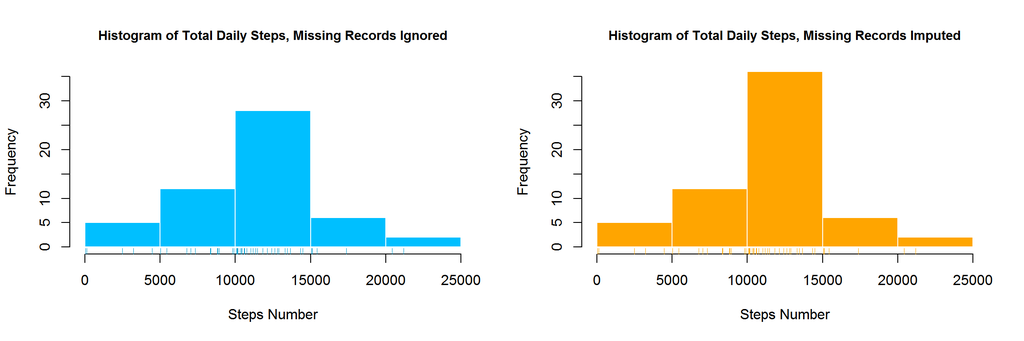

```r
par(mfrow =  c(1,2))
TitleHistogram = "Histogram of Total Daily Steps, Missing Records Ignored"
hist(TotalDailySteps$steps,
     col = "deepskyblue1",
     border="white",
     breaks = 5,
     main = TitleHistogram,
     cex.main = 0.9,
     xlab = "Steps Number",
     ylim = c(0, 35),
     xlim = c(0, 25000),
     cex = 0.85)
rug(TotalDailySteps$steps, col = "deepskyblue3")


TitleHistogram = "Histogram of Total Daily Steps, Missing Records Imputed"

hist(TotalDailyStepsNA_Imputed$steps,
     col = "orange",
     border="white",
     breaks = 5,
     main = TitleHistogram,
     cex.main = 0.9,
     xlab = "Steps Number",
     ylim = c(0, 35),
     xlim = c(0, 25000),
     cex = 0.85)
rug(TotalDailyStepsNA_Imputed$steps, col = "orange")
```

The diference vivid from the graph is that number of observations is higher, when using the average value for imputation.

The diference between the mean of data set with ignored missing records and the mean of data set with imputed missing is:

```r
abs(MeanOfTotalDailySteps - MeanOfTotalDailyStepsNA_Imputed)
```

```
## [1] 0
```

The diference between the median of data set with ignored missing records and the median of data set with imputed missing is:

```r
abs(MedianOfTotalDailySteps - MedianOfTotalDailyStepsNA_Imputed)
```

```
## [1] 1.188679
```

#### Are there differences in activity patterns between weekdays and weekends?

A new factor variable “weekday” is created in the data set with two levels: “weekdays” and “weekend”.

```r
DataNA_Imputed$weekdays <- factor(format(DataNA_Imputed$date, "%A"))
levels(DataNA_Imputed$weekdays)
```

```
## [1] "Friday"    "Monday"    "Saturday"  "Sunday"    "Thursday"  "Tuesday"
## [7] "Wednesday"
```

```r
Weekday = c("Monday", "Tuesday", "Wednesday", "Thursday", "Friday")
Weekend = c("Saturday", "Sunday")

levels(DataNA_Imputed$weekdays) <- list(weekday = Weekday, weekend = Weekend)
levels(DataNA_Imputed$weekdays)
```

```
## [1] "weekday" "weekend"
```

```r
table(DataNA_Imputed$weekdays)
```

```
##
## weekday weekend
##   12960    4608
```

The data is aggregated by 5-minutes interval and weekday/-end.

```r
AverageStepsNA_Imputed <- aggregate(DataNA_Imputed$steps,
                      list(interval = as.numeric(as.character(DataNA_Imputed$interval)),
                           weekdays = DataNA_Imputed$weekdays),
                      FUN = "mean")
names(AverageStepsNA_Imputed)[3] <- "AverageSteps"
```

The code below will produce the plot for average number of steps dueing the week and weekend.

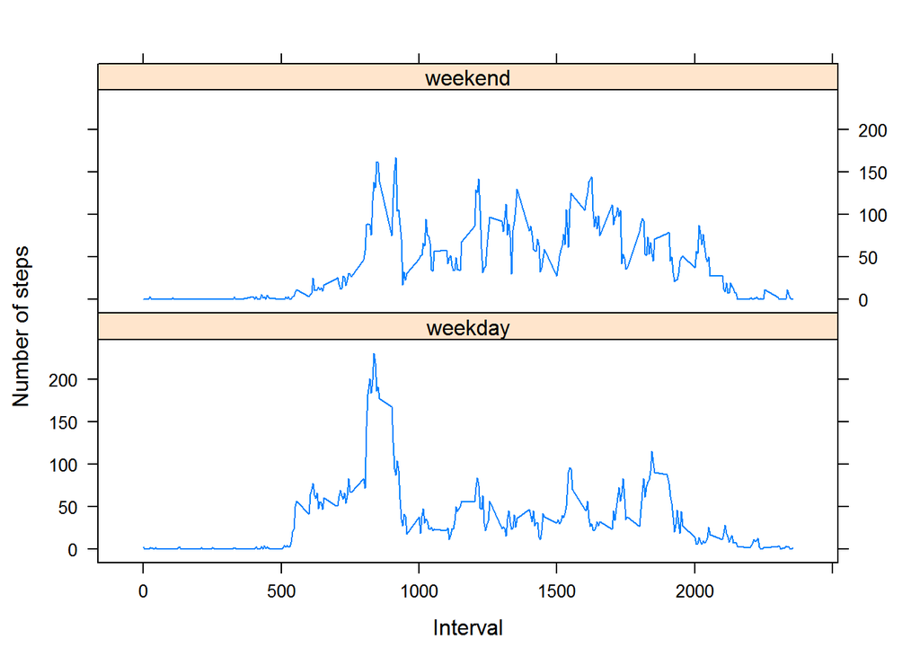

```r
library(lattice)
xyplot(AverageStepsNA_Imputed$AverageSteps ~ AverageStepsNA_Imputed$interval |
               AverageStepsNA_Imputed$weekdays,
       layout = c(1, 2), type = "l",
       xlab = "Interval", ylab = "Number of steps")
```

The diference between weekdays and weekend activity pattern is more vivid when both graphs are supperposed in the same graph:

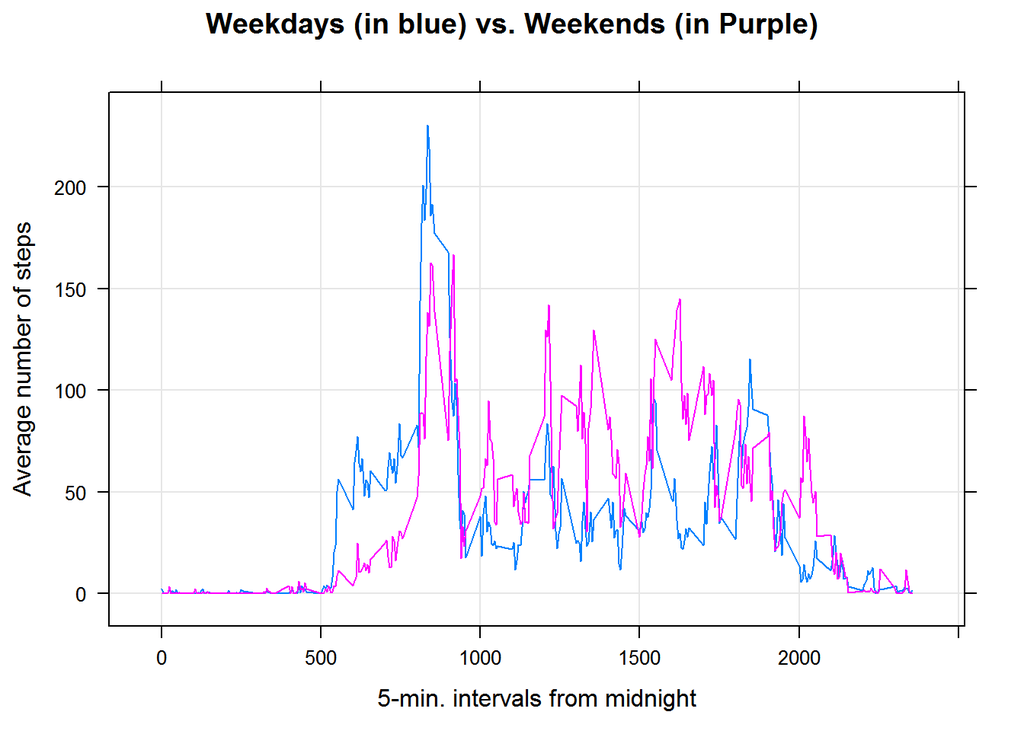

```r
xyplot(AverageSteps ~ interval,
       data = AverageStepsNA_Imputed,
       groups = AverageStepsNA_Imputed$weekdays,
       type = "l", grid=T,
       ylab = "Average number of steps",
       xlab = "5-min. intervals from midnight",
       main = "Weekdays (in blue) vs. Weekends (in Purple)")
```